# Real data analysis Silverman et al. (2018), http://dx.doi.org/10.1101/477794

Koen Van den Berge

# Load data, and estimate weights with ZINB-WaVE

```r
library(scRNAseq)
library(zinbwave)
library(tidyverse)
library(xtable)
library(ggridges)
library(BiocParallel)
library(doParallel)
NCORES <- 2
registerDoParallel(NCORES)
register(DoparParam())
# Preprocess and Run Model ------------------------------------------------
data("fluidigm")
# Remove lowly expressed genes as in vignette
filter <- rowSums(assay(fluidigm)>5)>5
table(filter)
```

```
filter
FALSE  TRUE
16127 10128
```

```r
fluidigm <- fluidigm[filter,]
# Take 100 most variables genes
assay(fluidigm) %>% log1p %>% rowVars -> vars
names(vars) <- rownames(fluidigm)
vars <- sort(vars, decreasing = TRUE)
head(vars)
```

```
 IGFBPL1    STMN2     EGR1   ANP32E    CENPF     LDHA
13.06109 12.24748 11.90608 11.67819 10.83797 10.72307
```

```r
fluidigm <- fluidigm[names(vars)[1:100],]
# just take biocondition
fluidigm <- fluidigm[,colData(fluidigm)$Biological_Condition %in% c("NPC" , "GW21")]
x <- colData(fluidigm)$Biological_Condition
#methods(class=class(fitZI))
fitZI <- zinbFit(fluidigm, X="~Biological_Condition + Coverage_Type")
weightsZinbwave <- computeObservationalWeights(fitZI,assays(fluidigm)[[1]])
fitNZI <- zinbFit(fluidigm, X="~Biological_Condition + Coverage_Type",
                  epsilon_min_logit=100000000000000)
```

# Fitting ZINB using EM-algorithm

zingeR (https://www.biorxiv.org/content/early/2017/06/30/157982) is another method that fits ZINB models. Whereas ZINB-WaVE uses penalized likelihood estimation, zingeR adopts the EM-algorithm to fit the ZINB models. zingeR uses the sequencing depth of the cell as co-data to aid with identifiability and identify excess zeros.

```r
## weights with zingeR
cond <- colData(fluidigm)$Biological_Condition
cov <- colData(fluidigm)$Coverage_Type
library(zingeR)
counts <- assays(fluidigm)[[1]]
weightsZinger <- zeroWeightsLS(counts, design=model.matrix(~cond+cov), verbose=FALSE)
```

```
converged.
```

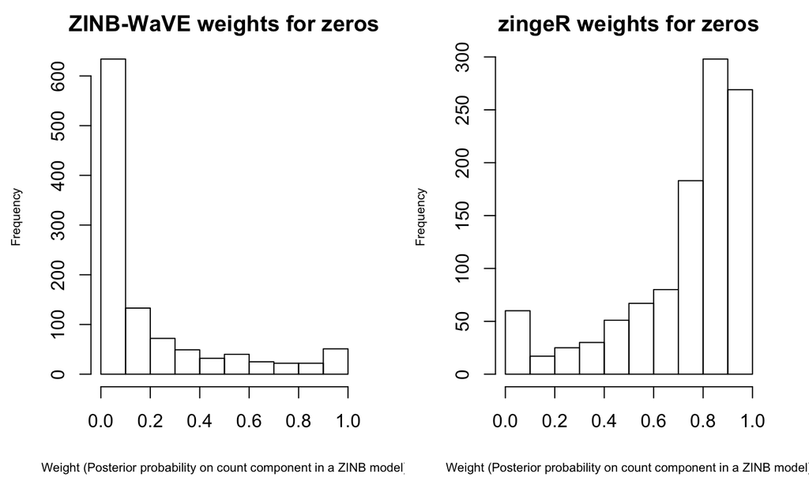

```r
par(mfrow=c(1,2))
hist(weightsZinbwave[counts==0], main="ZINB-WaVE weights for zeros", xlab="Weight (Posterior probability on count component in a ZINB model)", cex.lab=2/3)
hist(weightsZinger[counts==0], main="zingeR weights for zeros", xlab="Weight (Posterior probability on count component in a ZINB model)", cex.lab=2/3)
```

Note that ZINB-WaVE and zingeR give different results. It would require some work to assess goodness of fit, so it is unclear which model provides the best fit to the data.

# Assess effect of ZI

Let’s look at the SHISA2 gene, which was identified as a gene where results are very different when accounting for zero inflation in Silverman et al. (2018).

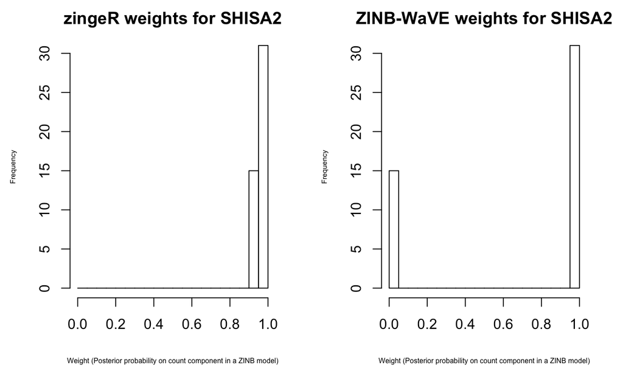

```r
par(mfrow=c(1,2))
hist(weightsZinger["SHISA2",], main="zingeR weights for SHISA2", xlab="Weight (Posterior probability on count component in a ZINB model)", xlim=c(0,1), breaks=seq(0,1,by=.05), cex.lab=1/2)
hist(weightsZinbwave[rownames(counts)%in%"SHISA2",], main="ZINB-WaVE weights for SHISA2", xlab="Weight (Posterior probability on count component in a ZINB model)", xlim=c(0,1), breaks=seq(0,1,by=.05), cex.lab=1/2)
```

Does the fold-change still differ substantially when accounting for ZI with zingeR?

```r
## ZI analysis
library(edgeR)
d <- DGEList(counts)
d <- calcNormFactors(d)
d$weights <- weightsZinger
design <- model.matrix(~cond+cov)
d <- estimateDisp(d,design)
fitZI <- glmFit(d,design)
lrtZI <- glmLRT(fitZI,coef=2)
## NB analysis
d <- DGEList(counts)
d <- calcNormFactors(d)
design <- model.matrix(~cond+cov)
d <- estimateDisp(d,design)
fitNB <- glmFit(d,design)
lrtNB <- glmLRT(fitNB,coef=2)
fitZI$coefficients["SHISA2",]
```

```
(Intercept)     condNPC      covLow
-12.9423488   9.8393721  -0.3161369
```

```r
fitNB$coefficients["SHISA2",]
```

```
(Intercept)     condNPC      covLow
-12.9620481   9.8599106  -0.3177843
```

No, fold-changes look pretty similar now.

How many fold-changes are switching signs when accounting for ZI, versus the NB model?

```r
switchSign <- !(sign(fitZI$coefficients[,2]) == sign(fitNB$coefficients[,2]))
mean(switchSign)
```

```
[1] 0.05
```

```r
switchSignId <- which(switchSign)
```

5 out of 100 genes switch signs in log-fold-change. A volcano plot shows that these are genes that had very low fold-changes in the NB model.

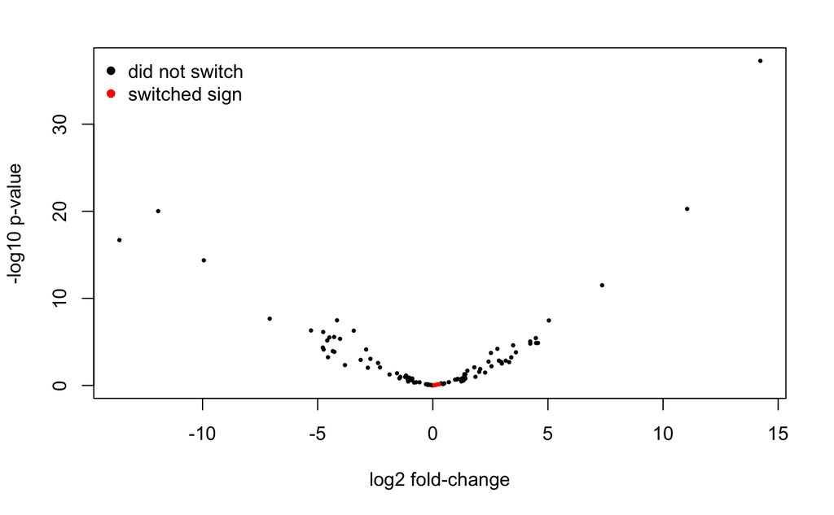

```r
plot(x=log2(exp(fitNB$coefficients[,2])), y=-log10(lrtNB$table$PValue), col=(1:2)[switchSign+1], pch=16, cex=1/2, xlab="log2 fold-change", ylab="-log10 p-value")
legend("topleft",c("did not switch","switched sign"), col=1:2, pch=16, bty='n')
```